# Vignette for fars functions

JLYJ

6 dec 2017

This vignette serves to illustrate how to use the farsfunctions package. The farsfunctions package, contains geodata for car accidents for each state in the US for the years 2013-2015.

The main function of the package is to visualize the accidents using the fars_map_state() function. The function takes two arguments, state number and year.

> fars_map_state(state.num = 44, year = 2013)

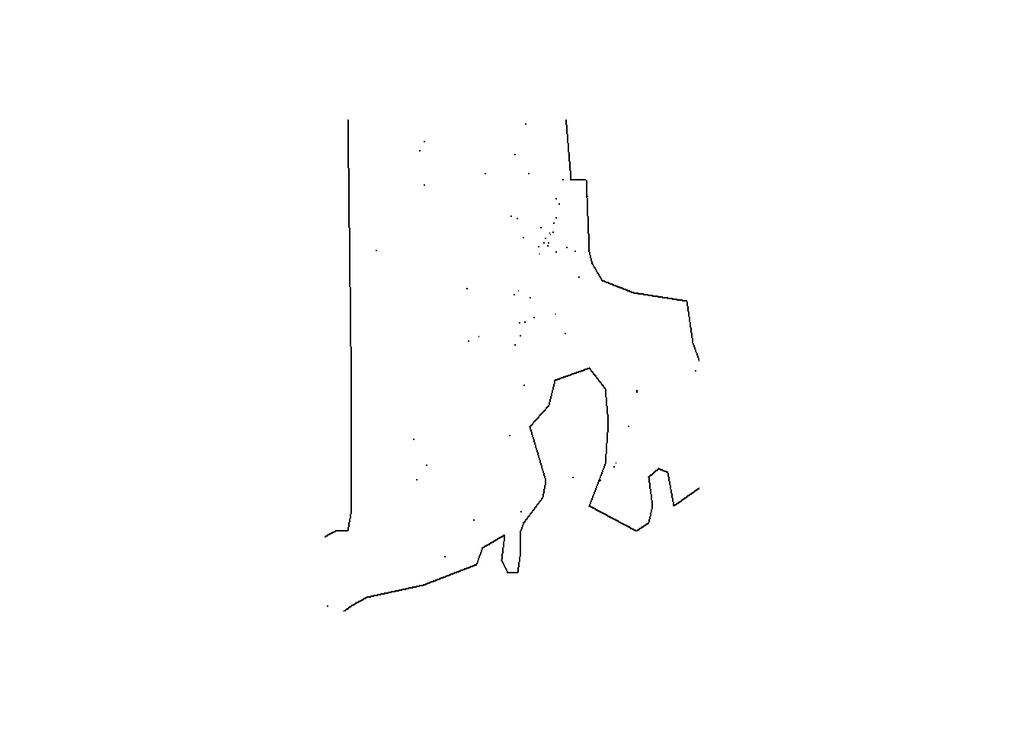

Another usefull function in the package is fars_summarize_years, which given a list of years, generates a summary table of the accidents for each month for the given years.

In addition to the main functions, a couple of helper functions are also included in the package. fars_read_years also takes a list of years and returns data for the given years (Not shown)

> fars_read_years(c(2013,2014))

Two other small functions are make_filename which takes a year as input, and returns the corresponding filename+incl. path, and fars_read, which given a filename reads the coresponding data into memory.

> make_filename(2013) fars_read()

```r
make_filename(2013)
```

```
## [1] "data/accident_2013.csv.bz2"
```

```r
fars_read("data/accident_2013.csv.bz2")
```

```
## # A tibble: 30,202 x 50
##    STATE ST_CASE VE_TOTAL VE_FORMS PVH_INVL  PEDS PERNOTMVIT PERMVIT
##    <int>   <int>    <int>    <int>    <int> <int>      <int>   <int>
##  1     1   10001        1        1        0     0          0       8
##  2     1   10002        2        2        0     0          0       2
##  3     1   10003        1        1        0     0          0       1
##  4     1   10004        1        1        0     0          0       3
##  5     1   10005        2        2        0     0          0       3
##  6     1   10006        2        2        0     0          0       3
##  7     1   10007        1        1        0     0          0       1
##  8     1   10008        2        2        0     0          0       2
##  9     1   10009        1        1        0     0          0       1
## 10     1   10010        2        2        0     0          0       4
## # ... with 30,192 more rows, and 42 more variables: PERSONS <int>,
## #   COUNTY <int>, CITY <int>, DAY <int>, MONTH <int>, YEAR <int>,
## #   DAY_WEEK <int>, HOUR <int>, MINUTE <int>, NHS <int>, ROAD_FNC <int>,
## #   ROUTE <int>, TWAY_ID <chr>, TWAY_ID2 <chr>, MILEPT <int>,
## #   LATITUDE <dbl>, LONGITUD <dbl>, SP_JUR <int>, HARM_EV <int>,
## #   MAN_COLL <int>, RELJCT1 <int>, RELJCT2 <int>, TYP_INT <int>,
## #   WRK_ZONE <int>, REL_ROAD <int>, LGT_COND <int>, WEATHER1 <int>,
## #   WEATHER2 <int>, WEATHER <int>, SCH_BUS <int>, RAIL <chr>,
## #   NOT_HOUR <int>, NOT_MIN <int>, ARR_HOUR <int>, ARR_MIN <int>,
## #   HOSP_HR <int>, HOSP_MN <int>, CF1 <int>, CF2 <int>, CF3 <int>,
## #   FATALS <int>, DRUNK_DR <int>
```